# Progress report 2

Pre-processing of paired-reads

Updated: 2019-05-15 11:53:37

## Read count

```
Number of forward reads before QC (Original_R1):     3634461 ( 100 % )
```

```
Number of reverse reads before QC (Original_R2):     3634461 ( 100 % )
```

```
Total Number of reads before QC:     7268922
```

## Read length

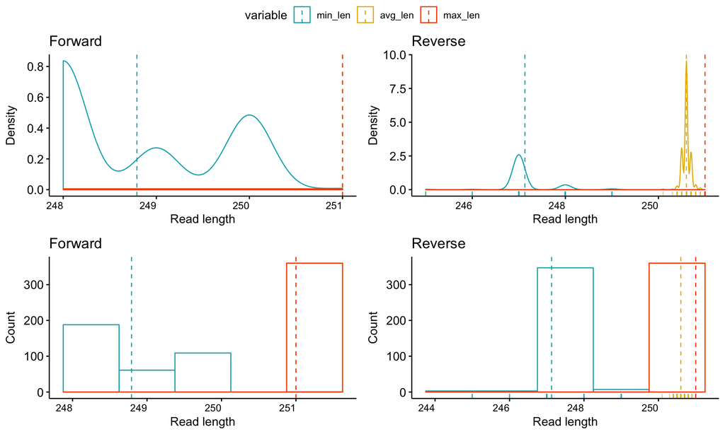

Figure x: Density and histograms plots showing forward and reverse read length. Dotted line indicates mean value for the specified variable

# Distribution of raw reads

## Barplots

**Grouped by Sex variable**

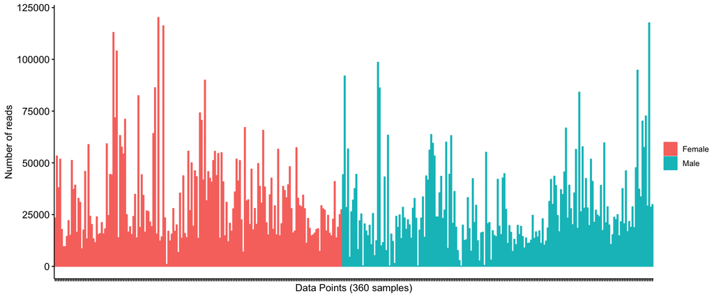

Figure x: Barplots of pre-processed reads grouped by sex variable.

**Grouped by Time variable**

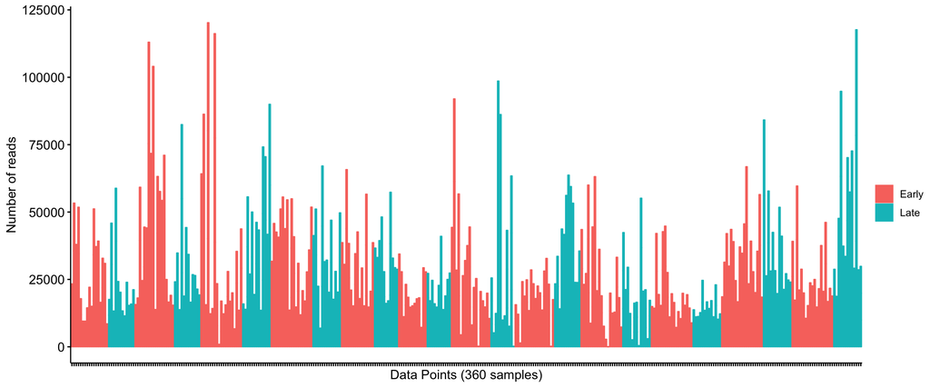

Figure x: Barplots of pre-processed reads grouped by time variable

**Grouped by days-post-weaning (D) variable**

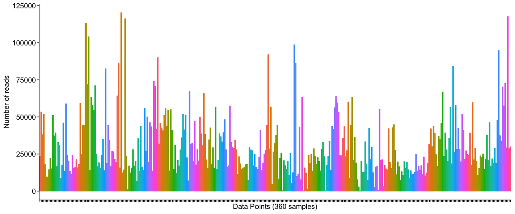

# Base call quality

- In the results folder you will find a folder named *multiqc* which contains data for HTML display. Right-click-open with your favorite browser
- Using CLI: Alternatively, open the HTML file on command line by running the following commands

## Original base call quality (qc0)

```
open ./results/multiqc/qc0/multiqc_report.html
open ./results/multiqc/qc0/R1/multiqc_report.html
open ./results/multiqc/qc0/R2/multiqc_report.html
```

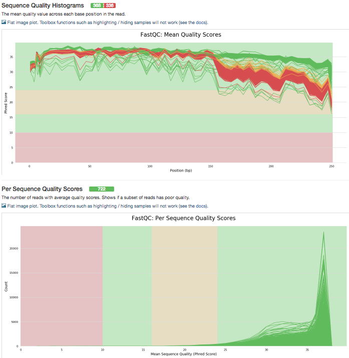

Figure x: Example of report generated by running **open ./results/multiqc/qc0/multiqc_report.html** on CLI

## Base call quality after trimming at Q = 25 (qctrim25)

```
open ./results/multiqc/qctrim25/multiqc_report.html
open ./results/multiqc/qctrim25/R1/multiqc_report.html
open ./results/multiqc/qctrim25/R2/multiqc_report.html
```

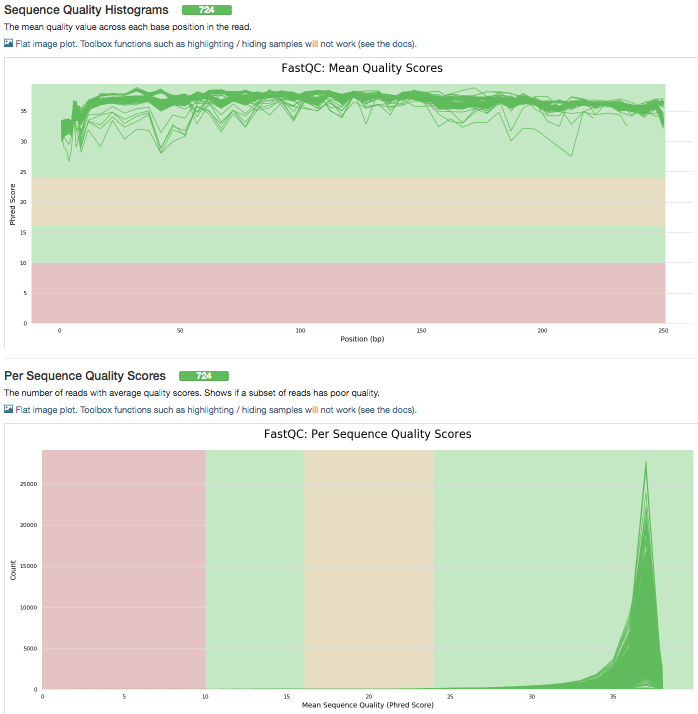

## Base call quality after removing phiX

```
open ./results/multiqc/qced/multiqc_report.html
open ./results/multiqc/qced/R1/multiqc_report.html
open ./results/multiqc/qced/R2/multiqc_report.html
```

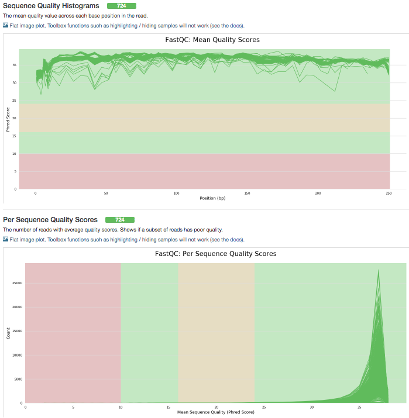

# Distribution of pre-processed reads

- Bar plots
- Box plots
- Density plots
- Histogram plots

## Stacked barplot

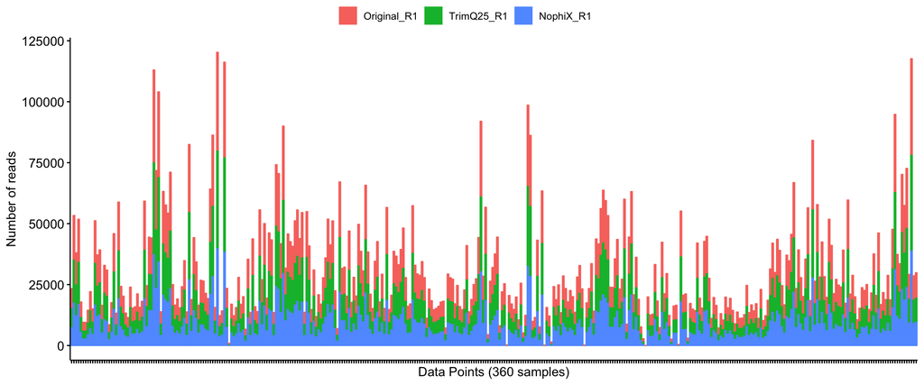

Figure x: Stacked barplots of pre-processed reads grouped by QC variable

## Boxplots

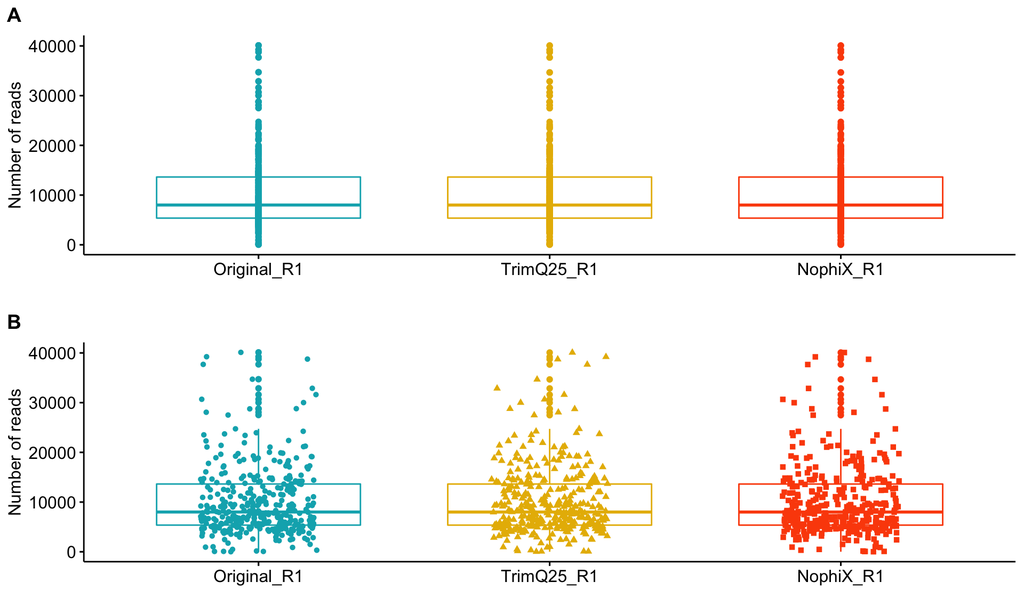

## Density plots

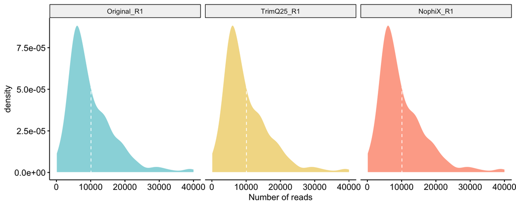

## Histograms

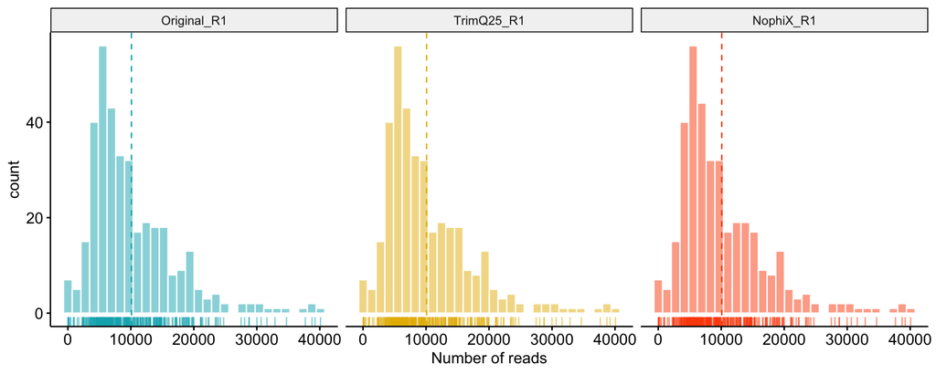

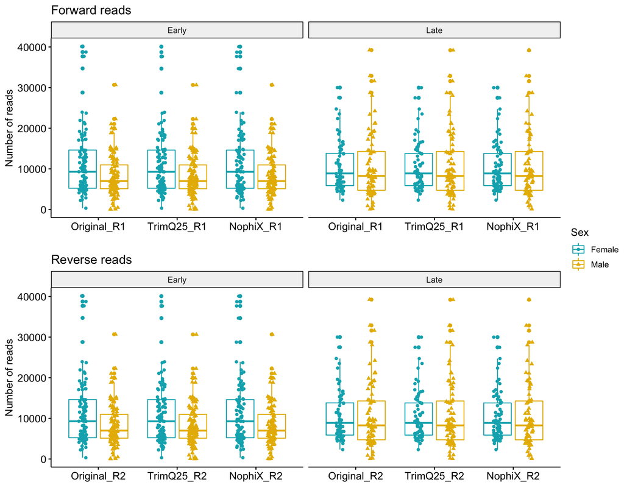

## Grouped by variable

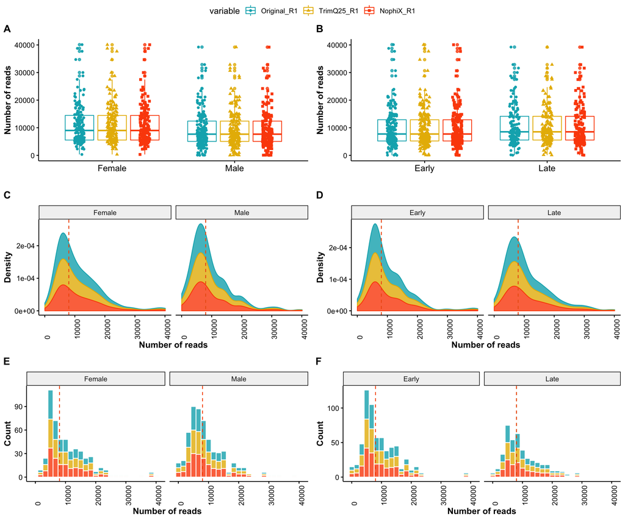

# Summary of pre-processed reads

## Total read count

- Sum of reads in all samples

```
Number of forward reads before QC (Original_R1):     3634461 ( 100 % )
```

```
Number of reverse reads before QC (Original_R2):     3634461 ( 100 % )
```

```
Number of forward reads after trimming at Q=25 (TrimQ25_R1):     3631940 ( 99.93064 % )
```

```
Number of reverse reads after trimming at Q=25 (TrimQ25_R2):     3631940 ( 99.93064 % )
```

```
Number of forward reads after phiX removal (NophiX_R1):  3631769 ( 99.92593 % )
```

```
Number of reverse reads after phiX removal (NophiX_R2):  3631769 ( 99.92593 % )
```

## Descriptive statistics

> Shows summary of the exact number of sequences remaining at each step in 4-quantiles.

```
  Original_R1      TrimQ25_R1      NophiX_R1      Original_R2
 Min.   :   14   Min.   :   14   Min.   :   14   Min.   :   14
 1st Qu.: 5368   1st Qu.: 5365   1st Qu.: 5365   1st Qu.: 5368
 Median : 8001   Median : 7996   Median : 7996   Median : 8001
 Mean   :10096   Mean   :10089   Mean   :10088   Mean   :10096
 3rd Qu.:13636   3rd Qu.:13630   3rd Qu.:13630   3rd Qu.:13636
 Max.   :40113   Max.   :40077   Max.   :40077   Max.   :40113
   TrimQ25_R2      NophiX_R2
 Min.   :   14   Min.   :   14
 1st Qu.: 5365   1st Qu.: 5365
 Median : 7996   Median : 7996
 Mean   :10089   Mean   :10088
 3rd Qu.:13630   3rd Qu.:13630
 Max.   :40077   Max.   :40077
```

# Posible questions

## At read inspection step

- QN1: Are there samples to be removed from the analysis based on read depth?
- QN2: Are there samples to be removed from the analysis based on read length?
- QN3: …….?
- QN4: …….?

## At base call quality checking step

- QN1: Are there samples to be removed from the analysis based on read quality?
- QN2: What are the minimum trimming parameters?
- QN3: Is trimming both ends necessary?
- QN4: Was phiX control used in the experiment, if so should removal of phiX contamination necessary?